# Novozhilov_testovoe

#### Задание

Предлагается предаггрегированные данные по пользователям Cust_id – идентификатор пользователя Source – утм-метки пользователя Orders – кол-во заказов пользователя LTV – Life time value: сколько принес пользователь за весь период жизни на платформе

1. Для каждой строки требуется вычленить source, medium, campaign пользователя
2. Посчитайте средний LTV на пользователя, и среднее кол-во заказов сравните поканально (source). Есть ли значимые различия?
3. Какой из каналов на ваш взгляд более эффективно работает
4. Можно ли оптимизировать каждый из каналов?

Предложите и посчитайте ещё 2-3 показателя, характеризующих качество групп привлекаемой аудитории. Проанализируйте полученные результаты и опишите суть различий между группами. Расчётную часть задачи выполните на Python. К заданию приложите ваш скрипт и краткий отчёт, включающий анализ и выводы

### или можно сразу перейти к выводам с картинками

```python
# уcтановка pandas_profiling: pip install pandas-profiling
import numpy as np
import pandas as pd
from urllib.parse import urlsplit, parse_qs
import matplotlib.pyplot as plt
import pandas_profiling
```

## 1.

###### Для каждой строки требуется вычленить source, medium, campaign пользователя

#### цсв -> датафрейм

```python
df = pd.read_csv('/Users/s.novozhilov/Downloads/data_test_mktg_anlst.csv', delimiter=';')
df.head(2)
```

|  | cust_id | source | orders | ltv |
| --- | --- | --- | --- | --- |
| 0 | 859 | ?utm_source=google&utm_medium=cpc&utm_campaign... | 28 | 913 |
| 1 | 232 | ?utm_source=google&utm_medium=cpc&utm_campaign... | 18 | 3157 |

#### Парсим метки, кладем в df

```python
def parse_utm(row, utm_name):
    query_string = urlsplit(row["source"]).query
    utm = parse_qs(query_string)
    return utm[utm_name][0]
```

```python
df["utm_source"] = df.apply(parse_utm, axis = 1, utm_name = "utm_source")
df["utm_medium"] = df.apply(parse_utm, axis = 1, utm_name = "utm_medium")
df["utm_campaign"] = df.apply(parse_utm, axis = 1, utm_name = "utm_campaign")
```

```python
df.head(3)
```

|  | cust_id | source | orders | ltv | utm_source | utm_medium | utm_campaign |
| --- | --- | --- | --- | --- | --- | --- | --- |
| 0 | 859 | ?utm_source=google&utm_medium=cpc&utm_campaign... | 28 | 913 | google | cpc | demographic_targets_male_age25-34 |
| 1 | 232 | ?utm_source=google&utm_medium=cpc&utm_campaign... | 18 | 3157 | google | cpc | demographic_targets_female_age18-24 |
| 2 | 2523 | ?utm_source=mytarget&utm_medium=cpc&utm_campai... | 1 | 1208 | mytarget | cpc | demographic_targets_male_age25-34 |

#### Дополнительно вытащим пол и возраст

```python
def demographic_parse(row, utm, feature):
    return row[utm].split('_')[feature]
df["sex"] = df.apply(demographic_parse, axis=1, utm="utm_campaign", feature=2)
df["age"] = df.apply(demographic_parse, axis=1, utm="utm_campaign", feature=3)
```

```python
#удаляем изначальные метки, чтобы не мешались
df.drop(['source'], axis='columns', inplace=True)
```

```python
# подготовленные данные
df.head(3)
```

|  | cust_id | orders | ltv | utm_source | utm_medium | utm_campaign | sex | age |
| --- | --- | --- | --- | --- | --- | --- | --- | --- |
| 0 | 859 | 28 | 913 | google | cpc | demographic_targets_male_age25-34 | male | age25-34 |
| 1 | 232 | 18 | 3157 | google | cpc | demographic_targets_female_age18-24 | female | age18-24 |
| 2 | 2523 | 1 | 1208 | mytarget | cpc | demographic_targets_male_age25-34 | male | age25-34 |

## 2.

##### Посчитайте средний LTV на пользователя, и среднее кол-во заказов сравните поканально (source). Есть ли значимые различия?

#### быстрая (но информативная) разведка данных

```python
pandas_profiling.ProfileReport(df)
```

[interactive chart not shown]

В данных пользователи уникальны. -> средний LTV на пользователя = средний LTV = **405.2**  
среднее кол-во заказов = **30.6**  
Распределения не перекошены, медианные значения LTV и заказов на уровне средних.

У юзеров из каналов "facebook", "google" и "mytarget" среднее LTV **360**, **463** и **409** соответственно.

Среднее кол-во заказов в каналах "google" и "mytarget" на одном уровне - 32,3 и 32,9. А вот из "facebook" делают в среднем на 7 заказов меньше (25,5).

*(Здесь и далее исходим из того, что все каналы запущены в одно время. Или среднее время с первого заказа для всех каналов одинаковое)*

| utm_source | cust_count | avg_orders | avg_ltv |
| --- | --- | --- | --- |
| facebook | 1501 | 25.5 | 359.5 |
| google | 1000 | 32.3 | 463.3 |
| mytarget | 2499 | 32.9 | 409.4 |

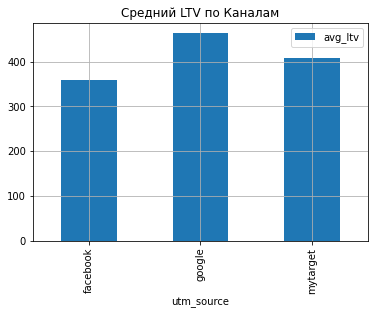

[figure not shown]

```python
#Средний LTV по Каналам
source_agg = df.groupby(by="utm_source").agg(cust_count = ('cust_id', 'count'),
         avg_orders = ('orders', 'mean'),
         avg_ltv = ('ltv', 'mean'),
         sum_orders = ('orders', 'sum'),
         sum_ltv = ('ltv', 'sum'),
        )
#график
source_agg.plot.bar(y="avg_ltv", grid = True, title = "Средний LTV по Каналам")
source_agg.plot.bar(y="avg_orders", grid = True, title = "Средний LTV по Каналам")
source_agg.iloc[:, 0:3].round(1)
```

## 3.

##### Какой из каналов на ваш взгляд более эффективно работает

Чтобы понять, какой канал наиболее эффективно работает, я предлагаю опираться не на средние метрики, а на суммарные.

Из канала "mytarget" пришло 50% клиентов - столько же, сколько из "google" и "facebook" вместе взятых.  
Суммарное количество заказов (82286) и суммарный LTV (1023034) составили больше остальных каналов вместе.

Не смотря на то, что средний LTV у пользователей из "google" чуть лучше, "mytarget" - самый эффективный канал.

```python
source_agg.iloc[:, 3:5]
```

| utm_source | sum_orders | sum_ltv |
| --- | --- | --- |
| facebook | 38300 | 539647 |
| google | 32303 | 463286 |
| mytarget | 82286 | 1023034 |

```
array([<AxesSubplot:ylabel='sum_orders'>, <AxesSubplot:ylabel='sum_ltv'>],
      dtype=object)
```

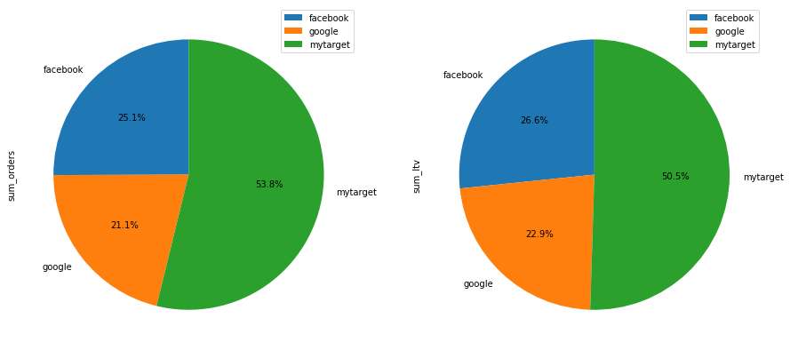

```python
(source_agg.iloc[:, 3:5]
     .plot.pie(subplots=True, figsize=(15, 15),autopct="%.1f%%", startangle=90))
```

## 4.

##### Можно ли оптимизировать каждый из каналов?

Как мы помним, у юзеров из "google" LTV больше, чем в других каналах (и больше среднего на 58 руб.) -> можем предположить, что повышение ставки* для этого канала (модель utm_medium=cpc для всех) позволит привлекать больше самых прибыльных клиентов.

Но сначала проверим, нет ли специфики таргетов среди каналов, возможно, мы сможем более точно настроить цены.  
Посмотрим распределение таргетов по полу и возрасту в рамках каналов.

Цель изменения ставок - повысить суммарный LTV всех пользователей, привлекая лучших клиентов.  
Рассматриваю отдельно аггрегации по полу и возрасту, не рассматриваю аггрегацию по utm_campaign, тк слишко мало клиентов для рассуждения

* *ставка = ставка или цена клика или закупаемый объем.*

```python
source_agg.iloc[:, 3:5]
```

| utm_source | sum_orders | sum_ltv |
| --- | --- | --- |
| facebook | 38300 | 539647 |
| google | 32303 | 463286 |
| mytarget | 82286 | 1023034 |

```python
#Пол по каналам
sex_agg = (df.groupby(by=["utm_source", "sex"]).agg(cust_count = ('cust_id', 'count'),
         avg_orders = ('orders', 'mean'),
         avg_ltv = ('ltv', 'mean')
        ))
```

```python
(sex_agg.round(0)
    .style
    .format("{:.0f}")
    .background_gradient(cmap='PuBu', axis=0))
```

| utm_source | sex | cust_count | avg_orders | avg_ltv |
| --- | --- | --- | --- | --- |
| facebook | female | 700 | 26 | 355 |
|  | male | 801 | 25 | 364 |
| google | female | 471 | 33 | 470 |
|  | male | 529 | 32 | 457 |
| mytarget | female | 1444 | 33 | 394 |
|  | male | 1055 | 33 | 430 |

```python
#Возраст по каналам
age_agg = (df.groupby(by=["utm_source", "age"]).agg(cust_count = ('cust_id', 'count'),
         avg_orders = ('orders', 'mean'),
         avg_ltv = ('ltv', 'mean')
        ))
```

```python
(age_agg.round(0)
    .style
    .format("{:.0f}")
    .background_gradient(cmap='PuBu', axis=0))
```

| utm_source | age | cust_count | avg_orders | avg_ltv |
| --- | --- | --- | --- | --- |
| facebook | age18-24 | 445 | 26 | 322 |
|  | age25-34 | 671 | 25 | 349 |
|  | age35 | 385 | 25 | 421 |
| google | age18-24 | 322 | 33 | 508 |
|  | age25-34 | 383 | 31 | 458 |
|  | age35 | 295 | 33 | 421 |
| mytarget | age18-24 | 833 | 33 | 358 |
|  | age25-34 | 1065 | 33 | 428 |
|  | age35 | 601 | 32 | 447 |

```python
#аггрегация по utm_campaign (пол+возраст) на всякий случай
```

```python
#Возраст по каналам
sex_age_agg = (df.groupby(by=["utm_source","sex", "age"]).agg(cust_count = ('cust_id', 'count'),
         avg_orders = ('orders', 'mean'),
         avg_ltv = ('ltv', 'mean')
        ))
```

```python
(sex_age_agg.round(0)
    .style
    .format("{:.0f}")
    .background_gradient(cmap='PuBu', axis=0))
```

| utm_source | sex | age | cust_count | avg_orders | avg_ltv |
| --- | --- | --- | --- | --- | --- |
| facebook | female | age18-24 | 445 | 26 | 322 |
|  |  | age35 | 255 | 25 | 411 |
|  | male | age25-34 | 671 | 25 | 349 |
|  |  | age35 | 130 | 25 | 440 |
| google | female | age18-24 | 322 | 33 | 508 |
|  |  | age35 | 149 | 32 | 387 |
|  | male | age25-34 | 383 | 31 | 458 |
|  |  | age35 | 146 | 34 | 454 |
| mytarget | female | age18-24 | 833 | 33 | 358 |
|  |  | age25-34 | 10 | 26 | 290 |
|  |  | age35 | 601 | 32 | 447 |
|  | male | age25-34 | 1055 | 33 | 430 |

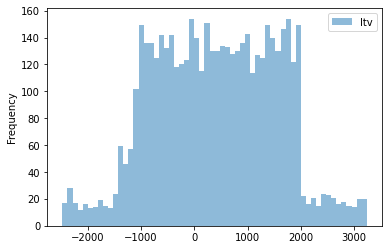

```python
df.iloc[:, 2:3].plot.hist(bins=60, alpha=0.5)
```

всё.

### Только Выводы

**2.** В данных пользователи уникальны. -> средний LTV на пользователя = средний LTV = **405,2**  
среднее кол-во заказов = **30,6**  
Распределения не перекошены, медианные значения LTV и заказов на уровне средних.

У юзеров из каналов "facebook", "google" и "mytarget" среднее LTV **360**, **463** и **409** соответственно.

Среднее кол-во заказов в каналах "google" и "mytarget" на одном уровне - 32,3 и 32,9. А вот из "facebook" делают в среднем на 7 заказов меньше (25,5)

| utm_source | cust_count | avg_orders | avg_ltv |
| --- | --- | --- | --- |
| facebook | 1501 | 25.5 | 359.5 |
| google | 1000 | 32.3 | 463.3 |
| mytarget | 2499 | 32.9 | 409.4 |

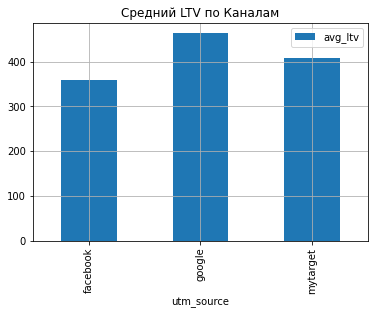

*Здесь и далее исходим из того, что все каналы запущены в одно время. Или среднее время с первого заказа для всех каналов одинаковое*

**3.** Чтобы понять, какой канал наиболее эффективно работает, я предлагаю опираться не на средние метрики, а на суммарные.

Из канала "mytarget" пришло 50% клиентов - столько же, сколько из "google" и "facebook" вместе взятых.  
Суммарное количество заказов (82286) и суммарный LTV (1023034) также составили больше остальных каналов вместе.

Не смотря на то, что средний LTV у пользователей из "google" чуть лучше, "mytarget" - самый эффективный канал.

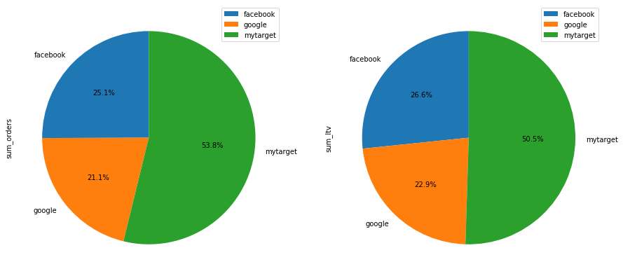

**4.** Как мы помним, у юзеров из "google" LTV больше, чем в других каналах (и больше среднего на 58 руб.) ->  
Можем предположить, что повышение ставки* для этого канала (модель utm_medium=cpc для всех) позволит привликать больше самых прибыльных клиентов.

Но сначала проверим, нет ли специфики таргетов среди каналов, возможно мы сможем более точно настроить цены.  
Посмотрим распределение таргетов по полу и возрасту в рамках каналов.

* ставка = ставка или цена клика, или закупаемый объем.

| utm_source | sex | cust_count | avg_orders | avg_ltv |
| --- | --- | --- | --- | --- |
| facebook | female | 700 | 26 | 355 |
|  | male | 801 | 25 | 364 |
| google | female | 471 | 33 | 470 |
|  | male | 529 | 32 | 457 |
| mytarget | female | 1444 | 33 | 394 |
|  | male | 1055 | 33 | 430 |

| utm_source | age | cust_count | avg_orders | avg_ltv |
| --- | --- | --- | --- | --- |
| facebook | age18-24 | 445 | 26 | 322 |
|  | age25-34 | 671 | 25 | 349 |
|  | age35 | 385 | 25 | 421 |
| google | age18-24 | 322 | 33 | 508 |
|  | age25-34 | 383 | 31 | 458 |
|  | age35 | 295 | 33 | 421 |
| mytarget | age18-24 | 833 | 33 | 358 |
|  | age25-34 | 1065 | 33 | 428 |
|  | age35 | 601 | 32 | 447 |

Цель изменения ставок - повысить суммарный LTV всех пользователей, привлекая лучших клиентов.  
Рассматриваем отдельно аггрегации по полу и по возрасту, а не аггрегацию по utm_campaign, тк в образованных группах часто слишком мало клиентов для вывода.

#### назад к расчетам